# World Development Indicators - 2022 Analysis

Zhaoxu Zhang

2025-02-25

## **Introduction**

- Understanding economic and social indicators is key to assessing global development.
- This analysis explores **three main indicators**:
  - **GDP per Capita** – Reflects economic strength.
  - **Life Expectancy** – Measures public health and living conditions.
  - **Unemployment Rate** – Indicates labor market stability.
- **Objective:** To analyze how these factors interrelate and their implications.

## **Data Overview**

- **Dataset:** Derived from the **World Bank’s World Development Indicators (2022)** (World Bank 2022).
- Focuses on **global economic and social statistics**.
- **Filtered Data:**
  - Year: **2022**
  - Key variables: **GDP per Capita, Life Expectancy, and Unemployment Rate**.

## **Exploratory Data Analysis**

- **What does the data tell us?**
- **Key Observations:**
  - **GDP per Capita** varies widely across countries.
  - **Life Expectancy** generally increases with economic development.
  - **Higher Unemployment** is often linked to **poorer health outcomes**.

### **Summary Statistics (2022)**

| Metric | Mean | Min | Max |
| --- | --- | --- | --- |
| GDP per Capita (USD) | 19,522 | 259 | 240,862 |
| Life Expectancy (yrs) | 72.45 | 52.99 | 85.38 |
| Unemployment Rate (%) | 7.02 | 0.13 | 37.85 |

## **Life Expectancy vs. Unemployment Rate**

- **How does unemployment affect life expectancy?**
- **Key Insights:**
  - Countries with **higher unemployment rates** often exhibit **lower life expectancy**.
  - Economies with stable job markets tend to have **better health outcomes**.

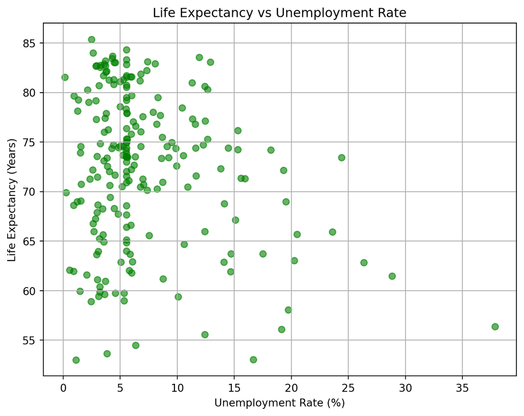

Life Expectancy vs. Unemployment Rate

## **Top 10 Countries by GDP per Capita**

- **Which countries have the highest GDP per capita?**
- **Key Observations:**
  - Wealthier nations **invest more in infrastructure and healthcare**.
  - Smaller, resource-rich countries dominate the rankings.

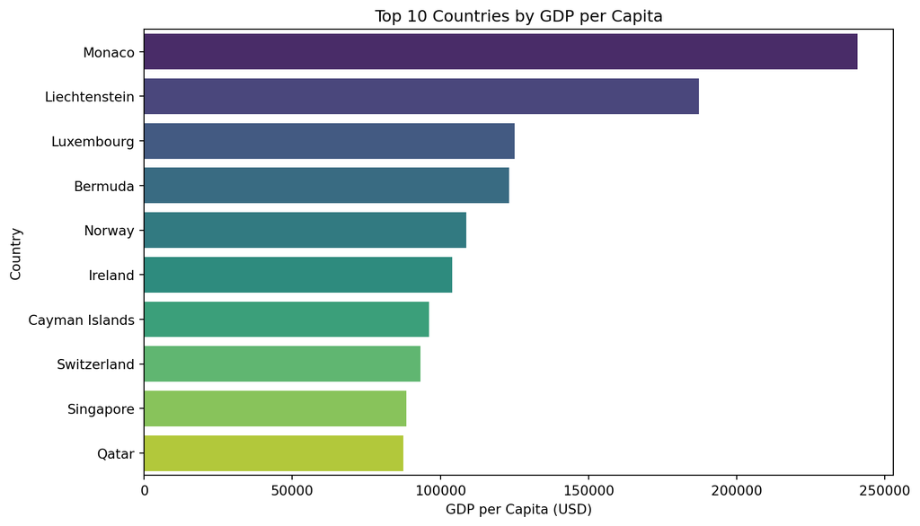

Top 10 Countries by GDP per Capita

## **Findings & Discussion**

According to the **United Nations (2022)** (United Nations 2022), economic stability plays a significant role in improving social welfare and long-term development.

### **1. GDP per Capita & Quality of Life**

- Higher **GDP per Capita** is strongly linked to **better healthcare and infrastructure**.
- Economic prosperity often correlates with **higher life expectancy**.

### **2. Unemployment & Health Impacts**

- High **Unemployment Rates** → **Lower Life Expectancy**.
- Countries with stable job markets tend to see **better overall well-being**.

### **3. Policy Implications**

- Economic policies should prioritize **job stability and social welfare**.
- Investments in **education, healthcare, and employment programs** are critical.

## **Conclusion**

- **Economic development alone is not enough** – stability in employment and strong healthcare systems are crucial.
- Countries that focus on **economic growth while ensuring job security** experience **higher overall well-being**.
- **Future Research:** Exploring **regional variations** in these indicators could provide more insights.

## **References**

United Nations. 2022. “Global Economic Outlook 2022.” https://www.un.org/development/global-economic-outlook.

World Bank. 2022. “World Development Indicators - 2022 Data.” https://databank.worldbank.org/source/world-development-indicators.